# Multiple regression lab

```r
library(dplyr)
library(PerformanceAnalytics)
library(car)
```

# Multiple regression analysis with a dataset on automobiles

Goal: analyse what is the best model to predict *cceleration* (`accel`, sec -from 0 to 100km/h) when you have two potential important covariates: *engine power* (`potenzacv`, horsepower) and *massa* (`massa`, kg).

## Data importing and cleaning

1. Import data (in ‘automobili.Rdata’) and form your current dataset of interest.

Check what you imported (have a look at the structure:

```r
automobili %>% str()
'data.frame':   189 obs. of  35 variables:
 $ marca          : Factor w/ 26 levels "alfa-romeo","audi",..: 1 1 1 1 1 1 1 1 1 1 ...
 $ modello        : Factor w/ 71 levels "","107","159-berlina",..: 3 4 4 42 42 42 42 42 42 42 ...
 $ allestimento   : Factor w/ 188 levels "107-10-68-cv-3p-access",..: 3 4 5 110 111 112 113 114 115 116 ...
 $ Crash.test.NCAP: int  5 5 5 5 5 5 5 5 5 5 ...
 $ prezzo         : int  27230 28440 31160 18770 20270 22370 23320 25020 22270 30200 ...
 $ carrozzeria    : chr  "berlina 2/4 porte" "station wagon" "station wagon" "berlina 3/5 porte" ...
 $ porte          : chr  "4" "5" "5" "5" ...
 $ posti          : chr  "5" "5" "5" "5" ...
 $ massa          : num  1490 1540 1540 1280 1280 1280 1290 1310 1310 1320 ...
 $ lung           : num  466 466 466 435 435 435 435 435 435 435 ...
 $ Larg           : num  183 183 183 180 180 180 180 180 180 180 ...
 $ alt            : num  142 143 143 147 147 147 147 147 146 147 ...
 $ passo          : num  270 270 270 263 263 263 263 263 263 263 ...
 $ bag_min        : num  405 445 445 350 350 350 350 350 350 350 ...
 $ bag_max        : num  0 1250 1250 1150 1150 1150 1150 1150 1150 1150 ...
 $ serbatoio      : num  70 70 70 60 60 60 60 60 60 60 ...
 $ motore         : chr  "4 cilindri in linea" "4 cilindri in linea" "4 cilindri in linea" "4 cilindri in linea" ...
 $ cilindri       : num  4 4 4 4 4 4 4 4 4 4 ...
 $ cilindrata     : num  1956 1956 1956 1368 1368 ...
 $ alimentazione  : chr  "gasolio(sovralimentato)" "gasolio(sovralimentato)" "gasolio(sovralimentato)" "benzina(sovralimentato)" ...
 $ alimentazione2 : Factor w/ 3 levels "benzina","gasolio",..: 2 2 2 1 1 1 1 1 2 1 ...
 $ trazione       : chr  "anteriore" "anteriore" "anteriore" "anteriore" ...
 $ potenza        : num  100 100 125 77 88 88 125 125 77 173 ...
 $ potenzacv      : num  136 136 170 105 120 120 170 170 105 235 ...
 $ giri           : num  4000 4000 4000 5000 5000 5000 5500 5500 4000 5500 ...
 $ coppia         : num  350 350 360 206 206 206 250 250 320 340 ...
 $ vel            : num  202 200 216 185 195 195 218 218 185 242 ...
 $ accel          : num  9.9 10.1 9 10.6 9.4 10.3 7.8 7.7 11.3 6.8 ...
 $ antinquin      : chr  "Euro5" "Euro5" "Euro5" "Euro5" ...
 $ emissioniCO2   : chr  "134" "137" "145" "149" ...
 $ cons.urbano    : num  6.6 6.8 7.2 8.4 8.4 8.5 7.8 5.6 5.5 10.8 ...
 $ cons.extraurb  : num  4.2 4.3 4.5 5.3 5.3 5.2 4.6 3.9 3.7 5.8 ...
 $ cons.misto     : num  5.1 5.2 5.5 6.4 6.4 6.4 5.8 4.5 4.4 7.6 ...
 $ codice_infocar : chr  "87371" "87373" "80956" "94236" ...
 $ url            : chr  "http://www.quattroruote.it/listino/alfa-romeo/159-berlina/159-20-jtdm-136-cv-progression" "http://www.quattroruote.it/listino/alfa-romeo/159-station/159-20-jtdm-136-cv-sw-progression" "http://www.quattroruote.it/listino/alfa-romeo/159-station/159-20-jtdm-sw-progression" "http://www.quattroruote.it/listino/alfa-romeo/giulietta/giulietta-14-turbo-105-cv" ...
```

or use View within Rstudio).

```r
View(automobili)
```

(Correct the class of `emissioniCO2`, though you can skip this point for now!)

Define row names by merging the first three columns (suggestion below).

```
?paste
row.names(automobili) <- ???(1st column, 2nd column, 3rd column)
```

Create dataset by selecting three variables (choose between `subset` or the “piping” syntax)

```
auto <- ???(automobili, select=c("accel","potenzacv","massa"))
# or
auto <- automobili %>% ???
```

```
'data.frame':   189 obs. of  3 variables:
 $ accel    : num  9.9 10.1 9 10.6 9.4 10.3 7.8 7.7 11.3 6.8 ...
 $ potenzacv: num  136 136 170 105 120 120 170 170 105 235 ...
 $ massa    : num  1490 1540 1540 1280 1280 1280 1290 1310 1310 1320 ...
                                                         accel potenzacv massa
alfa-romeo 159-berlina 159-20-jtdm-136-cv-progression      9.9       136  1490
alfa-romeo 159-station 159-20-jtdm-136-cv-sw-progression  10.1       136  1540
alfa-romeo 159-station 159-20-jtdm-sw-progression          9.0       170  1540
alfa-romeo giulietta giulietta-14-turbo-105-cv            10.6       105  1280
alfa-romeo giulietta giulietta-14-turbo-120-cv             9.4       120  1280
alfa-romeo giulietta giulietta-14-turbo-120-cv-gpl        10.3       120  1280
```

Export dataset.

```
write.table(auto, file="data/auto2.csv", ...)
```

Let’s start!

```r
d <- auto
```

## Exploring data

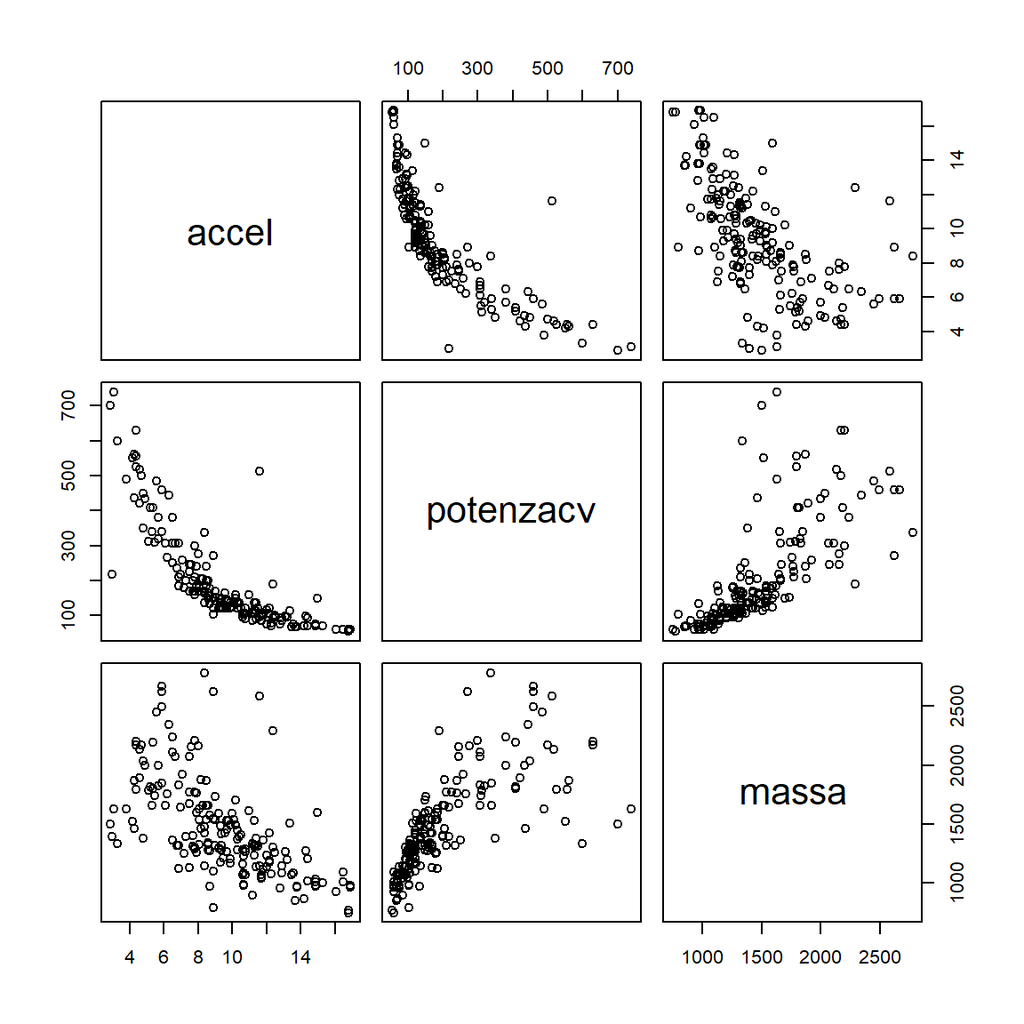

```r
pairs(d)
```

2. Comment on the relationship between variables. Are the direction of the relationships sensible?

An alternative to `pairs` is given by `chart.Correlation` from `PerformanceAnalytics` pkg.

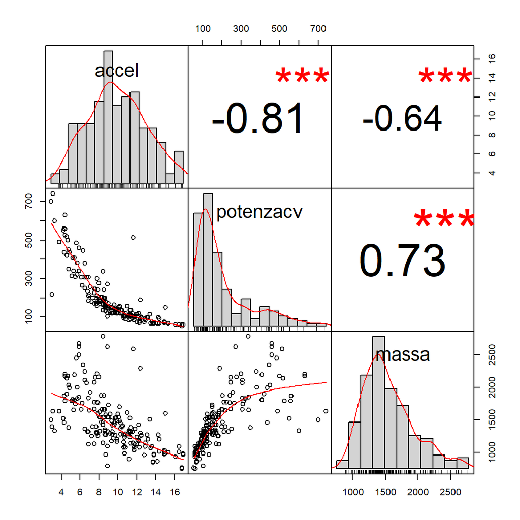

## Simple linear regression

3. We can start by fitting a simple linear regression of `accel` on `potenza`.

```
plot(???)

# play with identify(d$potenzacv, d$accel)
# or
# identify(d$potenzacv, d$accel, row.names(d))

fit0 <- lm(??? ~ ???, data = d)
abline(fit0)
```

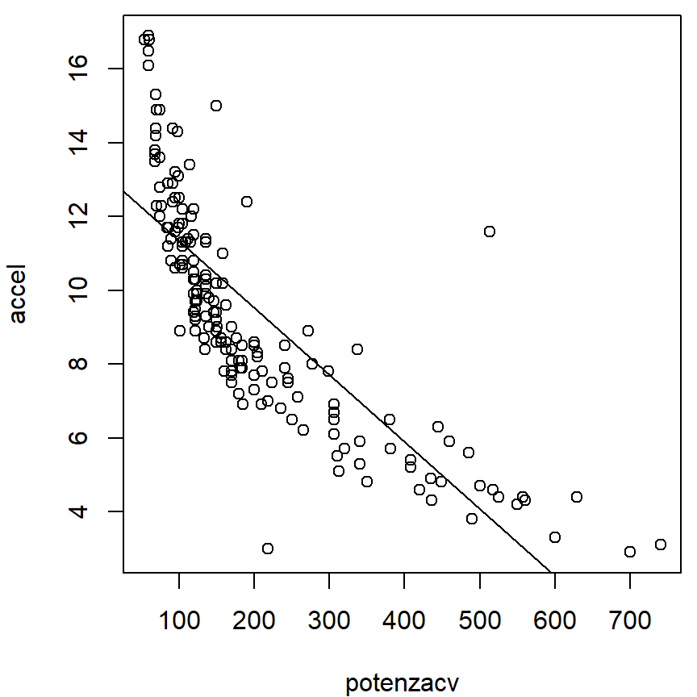

```r
summary(fit0)

Call:
lm(formula = accel ~ potenzacv, data = d)

Residuals:
    Min      1Q  Median      3Q     Max
-6.2123 -1.3307 -0.4314  1.0895  7.7535

Coefficients:
              Estimate Std. Error t value Pr(>|t|)
(Intercept) 13.1775112  0.2361521    55.8   <2e-16 ***
potenzacv   -0.0181892  0.0009572   -19.0   <2e-16 ***
---
Signif. codes:  0 '***' 0.001 '**' 0.01 '*' 0.05 '.' 0.1 ' ' 1

Residual standard error: 1.909 on 187 degrees of freedom
Multiple R-squared:  0.6588,    Adjusted R-squared:  0.657
F-statistic: 361.1 on 1 and 187 DF,  p-value: < 2.2e-16
```

4. Check the model.

   ```
   plot(???)
   ```

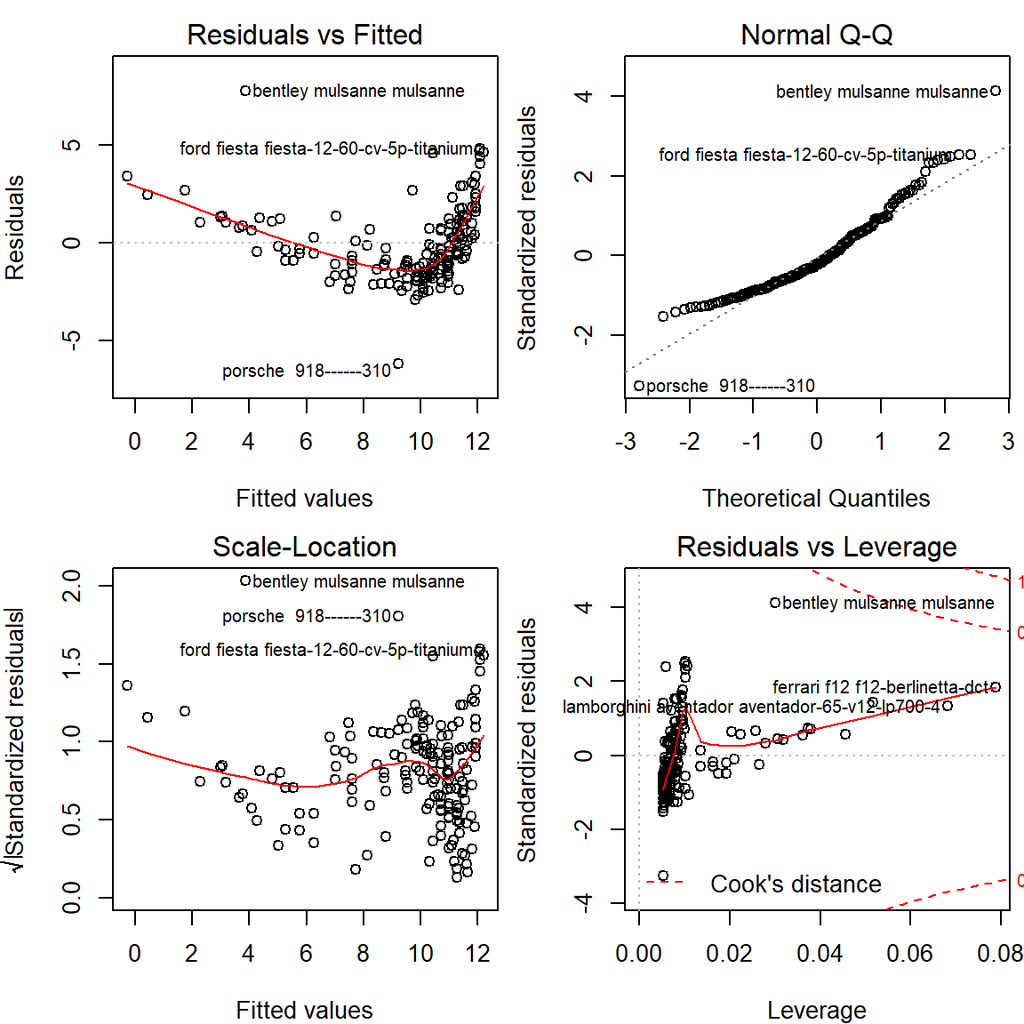

5. Examine whether transforming `potenza` into `log`’s or `sqrt`’s or reciprocals or reciprocals of `sqrt`’s makes the relationship linear (or (approximately linear).

   ```
   plot(???); plot(???); etc.
   ```

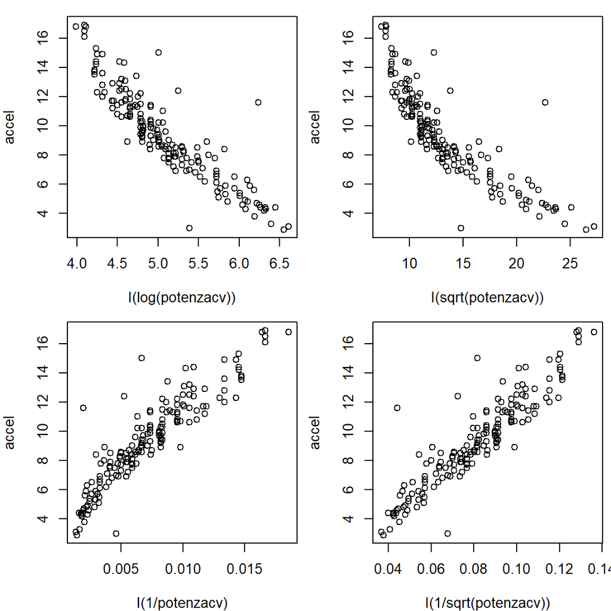

Look at the correlations.

```
cor(???); cor(???); etc.
```

```
-0.9107275  -0.868853  0.9253789  0.9296937
```

6. Now fit a linear model of accel on the properly transformed covariate, plot the regression line and, finally, check the model (look in particular at the first 4 diagnostic plots provided by R).

   ```
   fitrecsqrt <- lm(accel ~ ???, data=d)
   plot(???); ???
   plot(???, which=???)
   ```

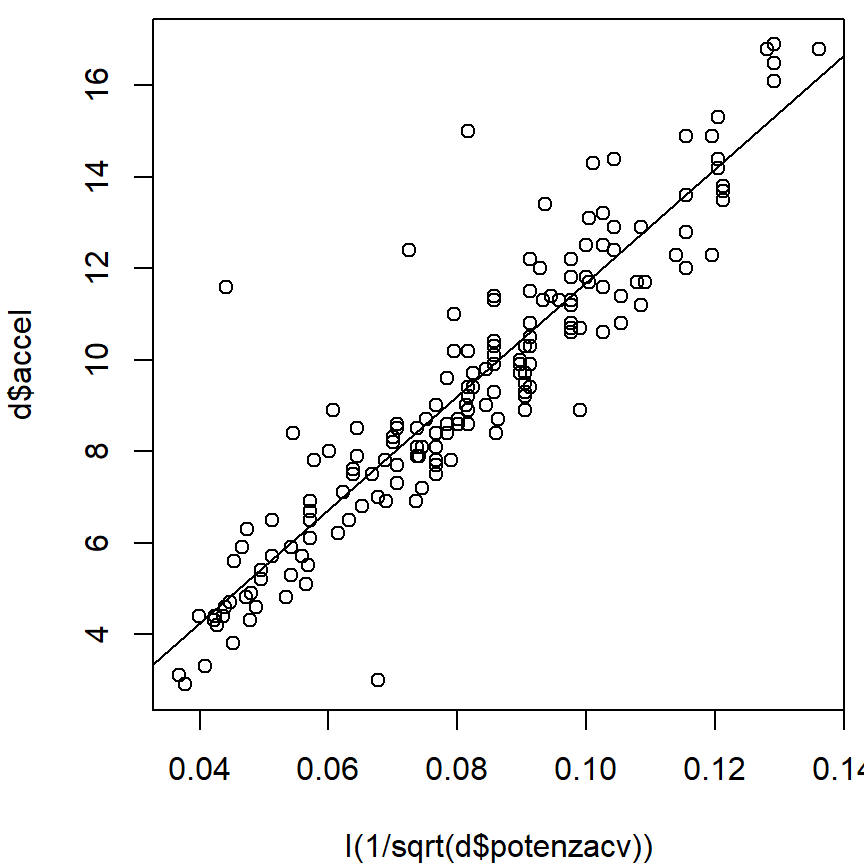

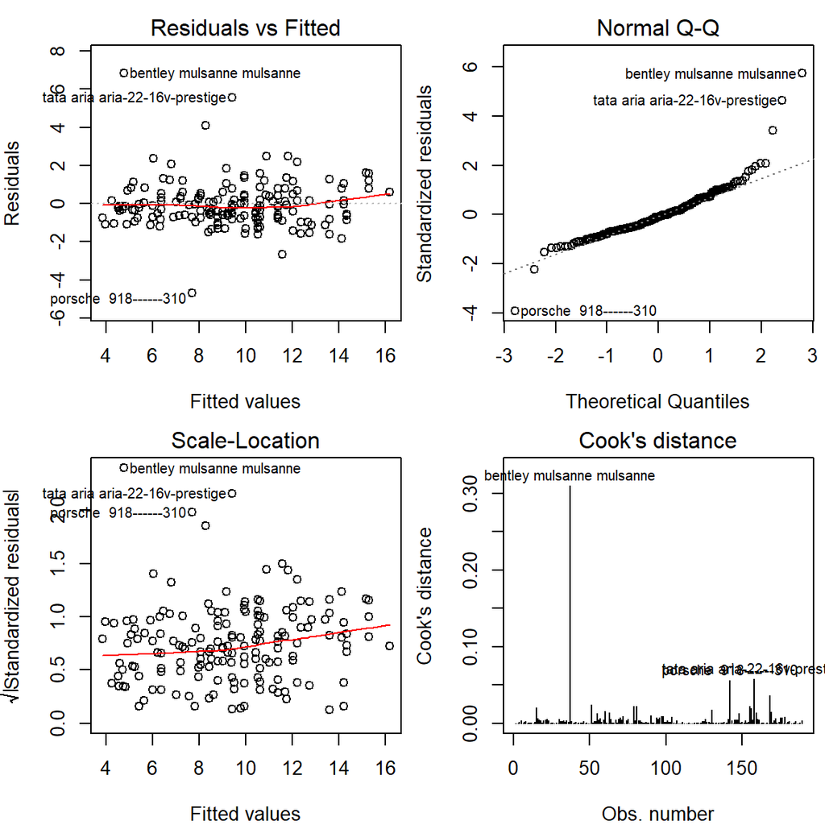

7. Look at coefs and error variance estimates, moreover, at R-squared.

```r
sfit <- summary(fitrecsqrt)
sfit

Call:
lm(formula = accel ~ I(1/sqrt(potenzacv)), data = d)

Residuals:
    Min      1Q  Median      3Q     Max
-4.6924 -0.7104 -0.1170  0.5374  6.8345

Coefficients:
                     Estimate Std. Error t value Pr(>|t|)
(Intercept)           -0.7155     0.3100  -2.308   0.0221 *
I(1/sqrt(potenzacv)) 124.1412     3.5966  34.516   <2e-16 ***
---
Signif. codes:  0 '***' 0.001 '**' 0.01 '*' 0.05 '.' 0.1 ' ' 1

Residual standard error: 1.204 on 187 degrees of freedom
Multiple R-squared:  0.8643,    Adjusted R-squared:  0.8636
F-statistic:  1191 on 1 and 187 DF,  p-value: < 2.2e-16
```

```r
names(sfit)
 [1] "call"          "terms"         "residuals"     "coefficients"
 [5] "aliased"       "sigma"         "df"            "r.squared"
 [9] "adj.r.squared" "fstatistic"    "cov.unscaled"
# Pull out coefs, sigma^2 and R^2
                        Estimate Std. Error   t value     Pr(>|t|)
(Intercept)           -0.7154919  0.3099897 -2.308115 2.208687e-02
I(1/sqrt(potenzacv)) 124.1411866  3.5966361 34.515915 4.829052e-83
[1] 1.449787
[1] 0.8643304
```

8. Build and plot the confidence and prediction interval along the entire range of the regressor (hint: an alternative to `matplot` is `curve`; see the help).

```
new_data <- data.frame(potenzacv = seq(min(d$potenzacv), max(d$potenzacv), length = 200))
A <- predict(???, newdata = ???, interval = ???)
B <- predict(???, newdata = ???, interval = ???)

matplot(new_data, cbind(A, B[, -1]), ...)
points(???, ???)

curve(predict(??? ???, etc), ???)
```

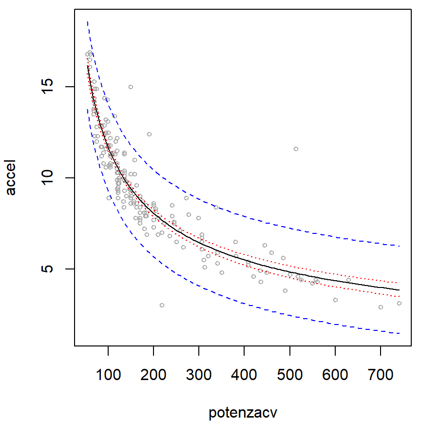

## Multivariable linear regression

If you skip the first section, you can read the data from auto2.csv directly.

```
d <- read.table(file=???, ...)
```

9. Looking at the scatterplot matrix above, does a model with both covariates make sense? (problems: underfitting?, overfitting?)
10. Now, first fit on the original (2) covariates, comment on the results, in particular the significance and interpretation of the coefs, and, finally, look briefly at residual analysis. Do we stop here?

```
fit0 <- lm(accel ~ potenzacv + massa, data=d)
summary(fit0)
plot(???)
```

```
Call:
lm(formula = accel ~ potenzacv + massa, data = d)

Residuals:
    Min      1Q  Median      3Q     Max
-6.3027 -1.2372 -0.4143  1.0673  8.1485

Coefficients:
              Estimate Std. Error t value Pr(>|t|)
(Intercept) 14.0649296  0.5517794  25.490   <2e-16 ***
potenzacv   -0.0164050  0.0013833 -11.859   <2e-16 ***
massa       -0.0008501  0.0004784  -1.777   0.0772 .
---
Signif. codes:  0 '***' 0.001 '**' 0.01 '*' 0.05 '.' 0.1 ' ' 1

Residual standard error: 1.898 on 186 degrees of freedom
Multiple R-squared:  0.6645,    Adjusted R-squared:  0.6609
F-statistic: 184.2 on 2 and 186 DF,  p-value: < 2.2e-16
```

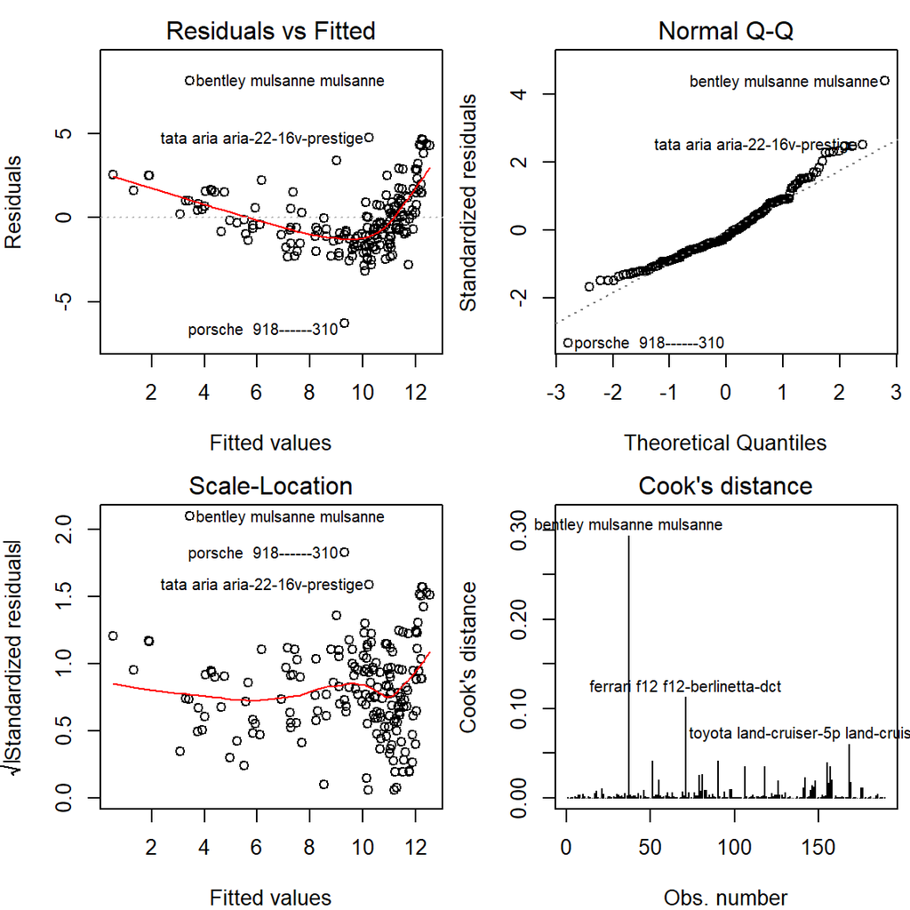

11. Fit a second model after somehow transforming variables.

```
fit1 <- lm(accel ~ I(1/sqrt(potenzacv)) + massa, data=d)
summary(???)
plot(???)
```

```
Call:
lm(formula = accel ~ I(1/sqrt(potenzacv)) + massa, data = d)

Residuals:
    Min      1Q  Median      3Q     Max
-3.8720 -0.5521 -0.1109  0.4410  5.2332

Coefficients:
                       Estimate Std. Error t value Pr(>|t|)
(Intercept)          -8.451e+00  8.230e-01 -10.268   <2e-16 ***
I(1/sqrt(potenzacv))  1.657e+02  5.127e+00  32.326   <2e-16 ***
massa                 2.938e-03  2.975e-04   9.872   <2e-16 ***
---
Signif. codes:  0 '***' 0.001 '**' 0.01 '*' 0.05 '.' 0.1 ' ' 1

Residual standard error: 0.978 on 186 degrees of freedom
Multiple R-squared:  0.911, Adjusted R-squared:   0.91
F-statistic: 951.7 on 2 and 186 DF,  p-value: < 2.2e-16
```

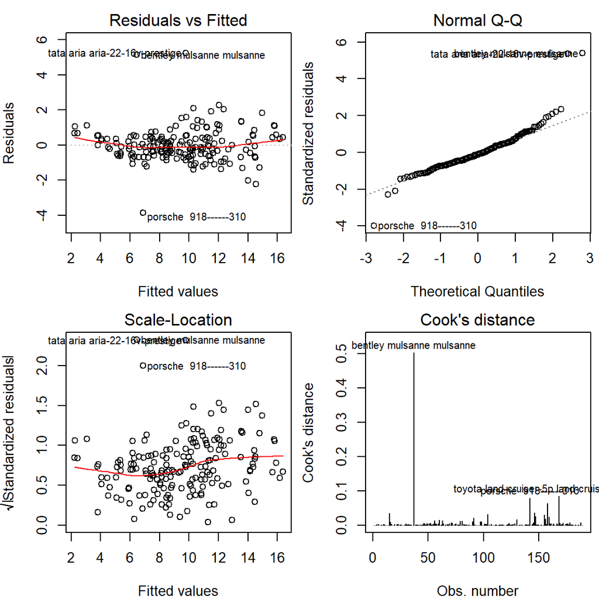

12. Comment on the coefficients estimate and whether this new model improves on the first model.
13. Compare the two models by hypothesis testing.

```
anova(model 1, model 2)
```

```
Analysis of Variance Table

Model 1: accel ~ I(1/sqrt(potenzacv))
Model 2: accel ~ I(1/sqrt(potenzacv)) + massa
  Res.Df    RSS Df Sum of Sq      F    Pr(>F)
1    187 271.11
2    186 177.90  1    93.215 97.461 < 2.2e-16 ***
---
Signif. codes:  0 '***' 0.001 '**' 0.01 '*' 0.05 '.' 0.1 ' ' 1
```

14. Can you compare fitrecsqrt to fit0? Why? Is mass an unnecessary variable?
15. A look at the variance inflation factor

```r
vif(fit1)
I(1/sqrt(potenzacv))                massa
            3.080442             3.080442
```

### Model representation (with multiple covariates)

16. First, you can represent the fitted model by plotting $(\hat y, y)$ or $(\hat y, e)$ and check the deviance of points from the respective ideal line.

```
plot(predicted y, y)
abline(0, 1)
plot(predicted y, residuals)
abline(???)
```

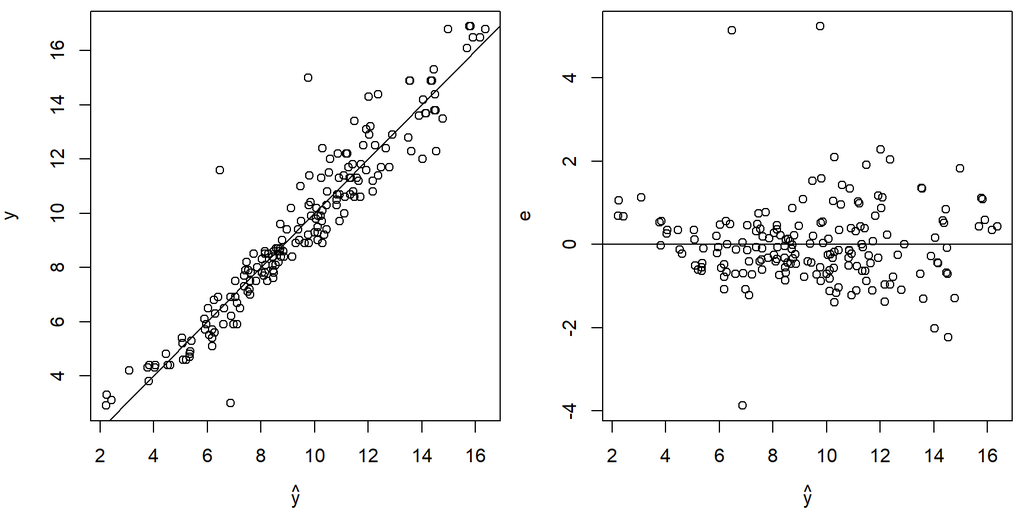

Now, let’s represent $y$ as function of the covariates.

Using $g(z)=\beta_0+\beta_1(1/\sqrt{z})+\bar x_2$ or $g(x)=\beta_0+\beta_1(1/\sqrt{\bar z})+x$ produces plots that are not straightforwardly interpretable. (Red dashes represent $\hat y$.)

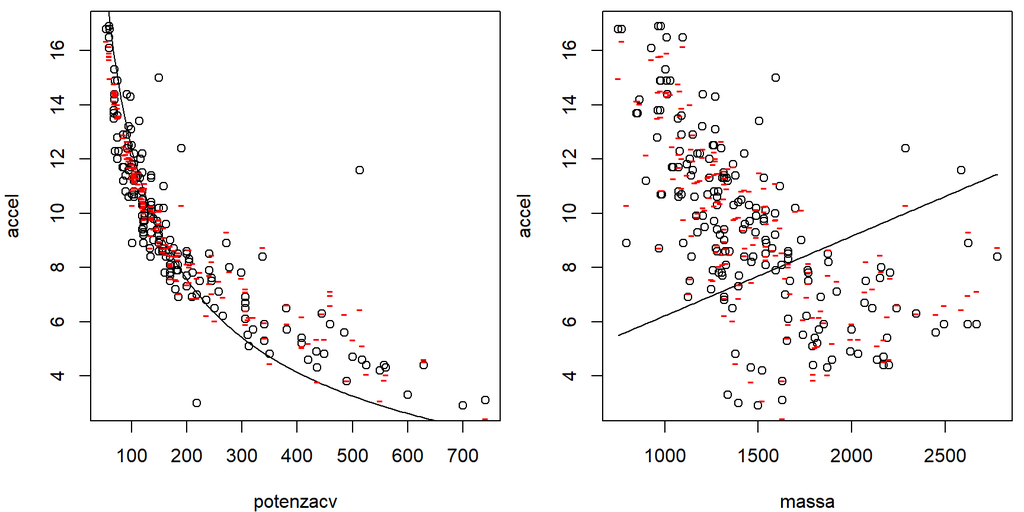

Instead, we can separate the contribute of individual covariates by fitting a line on the residuals of $y$ and each $x$ once fitted a regression model on the remaining covariates.

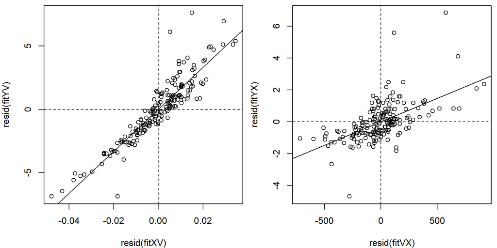

```r
fitYV = lm(accel ~ massa, data = d)
fitXV = lm(I(1/sqrt(potenzacv)) ~ massa, data = d)

plot(resid(fitYV) ~ resid(fitXV))
abline(h = 0, lty = 2)
abline(v = 0, lty = 2)
abline(lm(resid(fitYV) ~ resid(fitXV)))
summary(lm(resid(fitYV) ~ resid(fitXV)))

Call:
lm(formula = resid(fitYV) ~ resid(fitXV))

Residuals:
    Min      1Q  Median      3Q     Max
-3.8720 -0.5521 -0.1109  0.4410  5.2332

Coefficients:
               Estimate Std. Error t value Pr(>|t|)
(Intercept)  -2.088e-16  7.095e-02    0.00        1
resid(fitXV)  1.657e+02  5.113e+00   32.41   <2e-16 ***
---
Signif. codes:  0 '***' 0.001 '**' 0.01 '*' 0.05 '.' 0.1 ' ' 1

Residual standard error: 0.9754 on 187 degrees of freedom
Multiple R-squared:  0.8489,    Adjusted R-squared:  0.8481
F-statistic:  1051 on 1 and 187 DF,  p-value: < 2.2e-16

fitYX = lm(accel ~ I(1/sqrt(potenzacv)), data = d)
fitVX = lm(massa ~ I(1/sqrt(potenzacv)), data = d)

plot(resid(fitYX) ~ resid(fitVX))
abline(h = 0, lty = 2)
abline(v = 0, lty = 2)
abline(lm(resid(fitYX) ~ resid(fitVX)))
summary(lm(resid(fitYX) ~ resid(fitVX)))

Call:
lm(formula = resid(fitYX) ~ resid(fitVX))

Residuals:
    Min      1Q  Median      3Q     Max
-3.8720 -0.5521 -0.1109  0.4410  5.2332

Coefficients:
              Estimate Std. Error t value Pr(>|t|)
(Intercept)  1.299e-16  7.095e-02   0.000        1
resid(fitVX) 2.937e-03  2.968e-04   9.899   <2e-16 ***
---
Signif. codes:  0 '***' 0.001 '**' 0.01 '*' 0.05 '.' 0.1 ' ' 1

Residual standard error: 0.9754 on 187 degrees of freedom
Multiple R-squared:  0.3438,    Adjusted R-squared:  0.3403
F-statistic: 97.99 on 1 and 187 DF,  p-value: < 2.2e-16
```

17. What coincidence do you note?
18. What model assumption can you check with the above plots?

## A polynomial model for a nonlinear reationship

Let’s start with a quadratic polynomial.

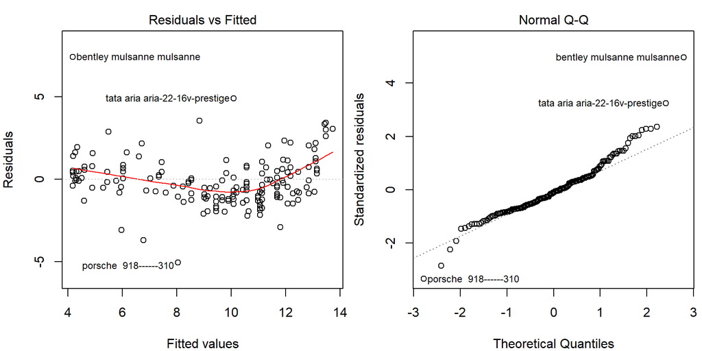

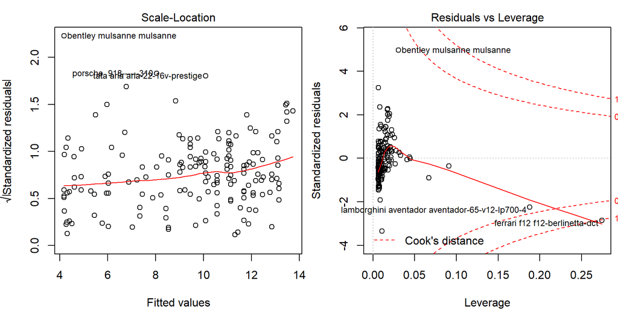

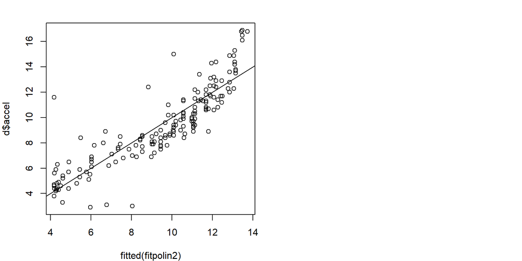

```r
fitpolin2 <- lm(accel ~ potenzacv + I(potenzacv^2), data = d)
summary(fitpolin2)

Call:
lm(formula = accel ~ potenzacv + I(potenzacv^2), data = d)

Residuals:
    Min      1Q  Median      3Q     Max
-5.0449 -0.9937 -0.1562  0.6630  7.4161

Coefficients:
                 Estimate Std. Error t value Pr(>|t|)
(Intercept)     1.615e+01  3.388e-01   47.68   <2e-16 ***
potenzacv      -4.744e-02  2.877e-03  -16.49   <2e-16 ***
I(potenzacv^2)  4.700e-05  4.457e-06   10.54   <2e-16 ***
---
Signif. codes:  0 '***' 0.001 '**' 0.01 '*' 0.05 '.' 0.1 ' ' 1

Residual standard error: 1.515 on 186 degrees of freedom
Multiple R-squared:  0.7865,    Adjusted R-squared:  0.7842
F-statistic: 342.5 on 2 and 186 DF,  p-value: < 2.2e-16

plot(fitpolin2)
plot(fitted(fitpolin2), d$accel)
abline(0, 1)
```

19. Are you satisfied from the check?
20. Update the model adding the cubic power and compare to the previous model.

```
fitpolin3 <- update(???, .~.+???)
summary(fitpolin3)

???
???
```

```
Call:
lm(formula = accel ~ potenzacv + I(potenzacv^2) + I(potenzacv^3),
    data = d)

Residuals:
    Min      1Q  Median      3Q     Max
-4.3106 -0.8325 -0.1879  0.5957  6.0185

Coefficients:
                 Estimate Std. Error t value Pr(>|t|)
(Intercept)     1.959e+01  4.872e-01  40.201  < 2e-16 ***
potenzacv      -9.633e-02  6.120e-03 -15.740  < 2e-16 ***
I(potenzacv^2)  2.198e-04  2.021e-05  10.876  < 2e-16 ***
I(potenzacv^3) -1.662e-07  1.910e-08  -8.703 1.76e-15 ***
---
Signif. codes:  0 '***' 0.001 '**' 0.01 '*' 0.05 '.' 0.1 ' ' 1

Residual standard error: 1.279 on 185 degrees of freedom
Multiple R-squared:  0.8485,    Adjusted R-squared:  0.846
F-statistic: 345.3 on 3 and 185 DF,  p-value: < 2.2e-16
Analysis of Variance Table

Model 1: accel ~ potenzacv + I(potenzacv^2)
Model 2: accel ~ potenzacv + I(potenzacv^2) + I(potenzacv^3)
  Res.Df    RSS Df Sum of Sq      F    Pr(>F)
1    186 426.72
2    185 302.77  1    123.96 75.742 1.756e-15 ***
---
Signif. codes:  0 '***' 0.001 '**' 0.01 '*' 0.05 '.' 0.1 ' ' 1
```

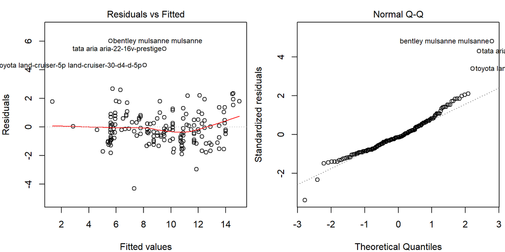

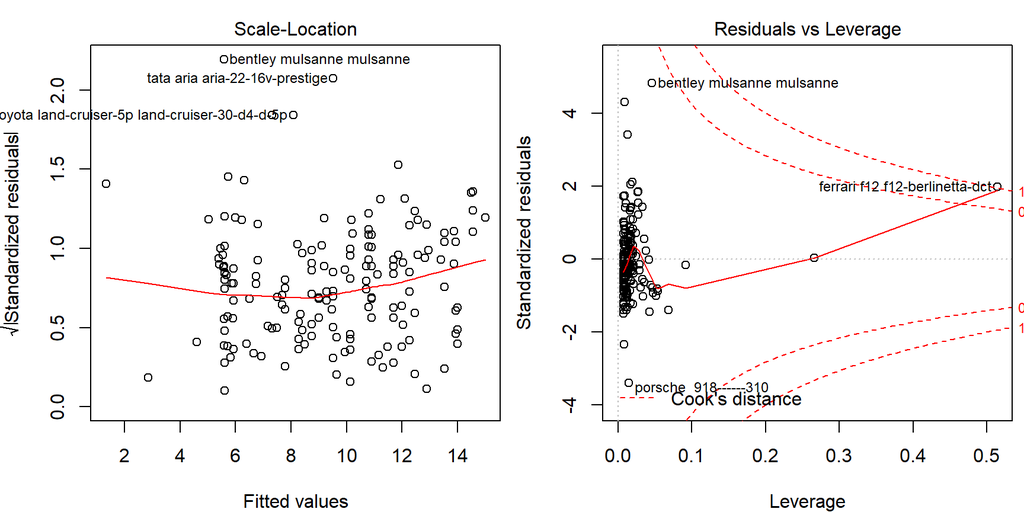

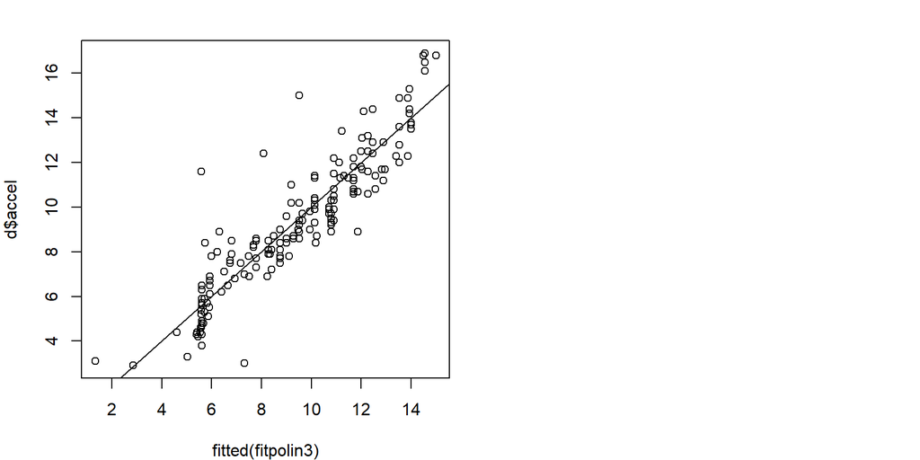

21. Was it really worth the effort if we compare it to the simple regr model?
22. Look at the fitted model on the observed data. What do you note?

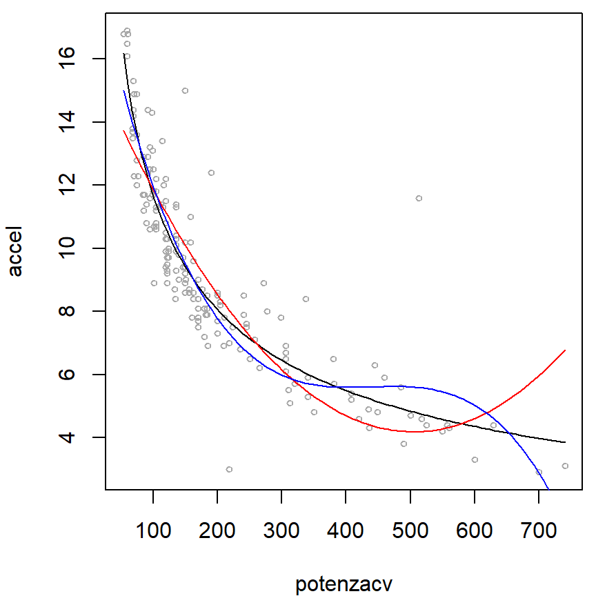

Matilde Trevisani

2018-10-22